# Project Machine Learning

Marco Guado

August 21, 2016

## Final Project

### 2. Objective

It is to be determined based on the values collected, what is the best exercise routine with weights, using a classification algorithm.

### 3. Data to be used

Download the data set.

```r
url_data_training <- "http://d396qusza40orc.cloudfront.net/predmachlearn/pml-training.csv";
url_data_testing <- "http://d396qusza40orc.cloudfront.net/predmachlearn/pml-testing.csv";

df_training <- read.csv(url(url_data_training));
df_testing <- read.csv(url(url_data_testing));

tmp_df_training <- df_training[, c(8:160)];
tmp_df_testing <- df_testing[, c(8:160)];

length(df_training)
```

```
## [1] 160
```

```r
nrow(df_training)
```

```
## [1] 19622
```

```r
length(df_testing)
```

```
## [1] 160
```

```r
nrow(df_testing)
```

```
## [1] 20
```

### 4. Analysis of data

We have two sets of data; First the “formation” and the second “test” in this data set there are columns whose value = NA, which will filter since they are not useful for analysis.

```r
#Clean data
not.na <- function(){
    pos_columns <- c()
    for(column in c(1:153)){
        exist.na <- sum(is.na(tmp_df_testing[,column]))
        if(20 == exist.na ){
            #print("exist")
        }else{
            #print("not exist")
            pos_columns <- c(pos_columns, column)
        }
    }
    return(pos_columns)
}

columns <- not.na();

#We create two new data set that will be used for analysis
new_df_training <- tmp_df_training[, columns];
new_df_testing <- tmp_df_testing[, columns];
```

After analyzing the data, we note that we have 52 predictor variables and a discriminant variable called “classe”.

Classification models that contain both quantitative and qualitative variables can be solved using the following algorithms:  
• Random Forest  
• Neural Networks  
• Bagging  
• Classification Trees

For this project we will use “Random Forest” based on what was observed in the data set:  
- We have many variables  
- We can determine which variables are most important  
- We want to get good accuracy

We process the data:

```r
library(randomForest);
df_model<-randomForest(classe ~ ., data=new_df_training, ntree=30, mtry=6, replace=T);

print(df_model)
```

```
##
## Call:
##  randomForest(formula = classe ~ ., data = new_df_training, ntree = 30,      mtry = 6, replace = T)
##                Type of random forest: classification
##                      Number of trees: 30
## No. of variables tried at each split: 6
##
##         OOB estimate of  error rate: 0.65%
## Confusion matrix:
##      A    B    C    D    E class.error
## A 5574    1    0    4    1 0.001075269
## B   21 3767    9    0    0 0.007900974
## C    0   28 3377   15    2 0.013150205
## D    1    2   27 3184    2 0.009950249
## E    0    5    5    5 3592 0.004158581
```

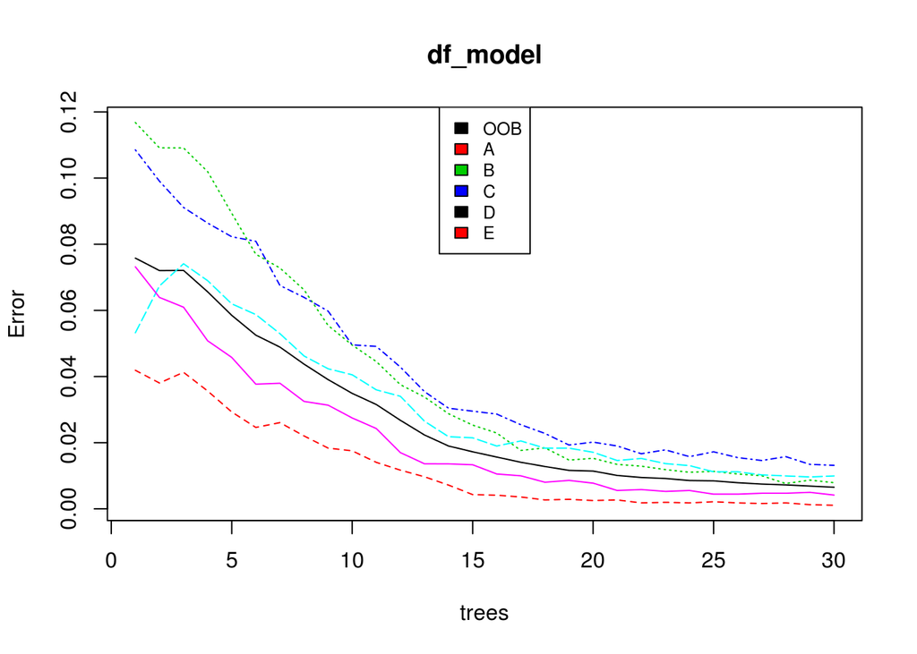

```r
plot(df_model)
legend("top", colnames(df_model$err.rate),col=1:4,cex=0.8,fill=1:4)
```

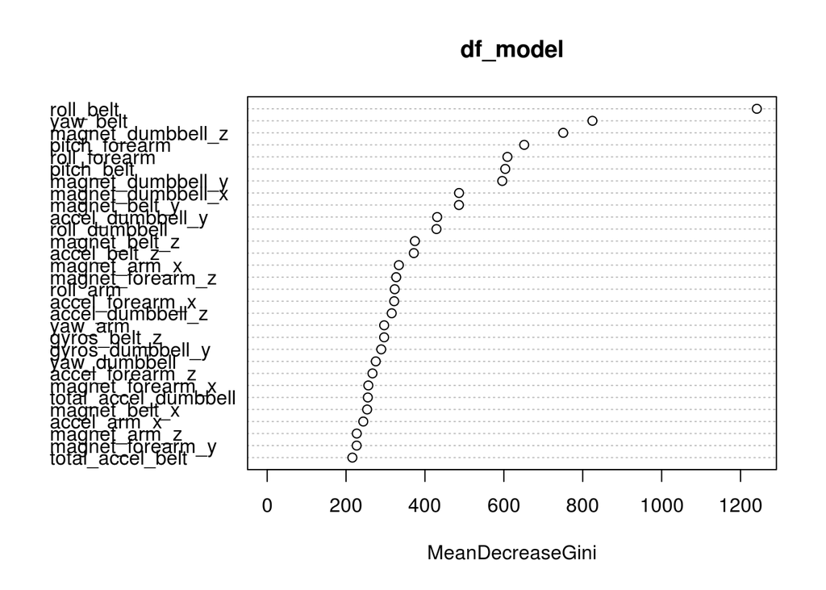

```r
varImpPlot(df_model)
```

```r
predict(df_model, new_df_testing)
```

```
##  1  2  3  4  5  6  7  8  9 10 11 12 13 14 15 16 17 18 19 20
##  B  A  B  A  A  E  D  B  A  A  B  C  B  A  E  E  A  B  B  B
## Levels: A B C D E
```

### 5. Conclusions

When using random forest algorithm we can see that the error rate is very low with which we can trust the results and that our model can be useful for other predictions.